# Simulation mit Python

## Lernziele

Goal of the next two units is to create a simple simulation model of a building energy system from scratch.

The simulation model will be used in the subsequent optimization course by Bernhard Heinzl.

## Leistungsbeurteilung:

- Präsentation
- mit Prüfungsgespräch (2er Teams)

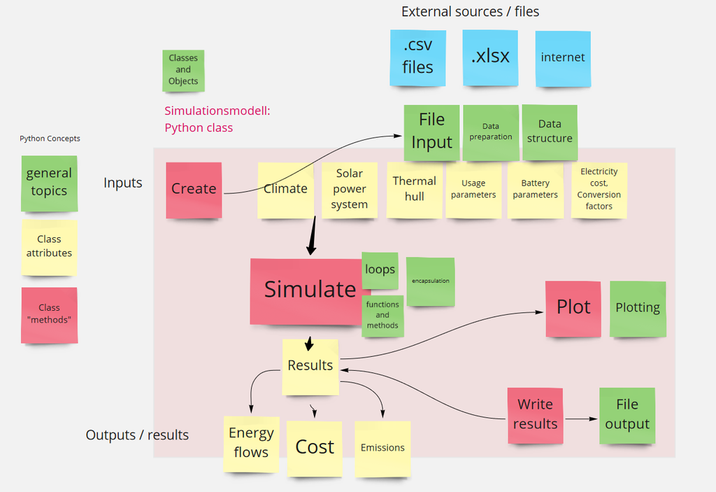

## Ablauf

**17:00 - 19:00** 1 Hour Input, 1 Hour Workshop

- Setup
- Review of the basics. [lecturer link](http://localhost:8888/notebooks/PycharmProjects/scientific-python-lectures/Lecture-1-Introduction-to-Python-Programming.ipynb#) [**im internet**](https://nbviewer.jupyter.org/github/jrjohansson/scientific-python-lectures/blob/master/Lecture-1-Introduction-to-Python-Programming.ipynb)
- Differences between Matlab and Python [**im internet**](https://realpython.com/matlab-vs-python/#syntax-differences-between-matlab-and-python)
- Finalization and Review of the exercises
  - [**im internet**](https://holypython.com/beginner-python-exercises/exercise-10-len-function/)
  - [lecturer link](http://localhost:8888/notebooks/PycharmProjects/MEE-BB-2-SS2021-AS-Simulation/1%20Basics.ipynb#Review-der-Exercises-und-Selbsttest-Aufgaben)

**19:00 - 21:00** 1 Hour Input, 1 Hour Workshop

- Working with data
  - Numpy [lecturer](http://localhost:8888/notebooks/PycharmProjects/scientific-python-lectures/Lecture-2-Numpy.ipynb) [**im internet**](https://nbviewer.jupyter.org/github/jrjohansson/scientific-python-lectures/blob/master/Lecture-2-Numpy.ipynb)
  - Matplotlib [lecturer link](http://localhost:8888/notebooks/PycharmProjects/scientific-python-lectures/Lecture-4-Matplotlib.ipynb) [**im internet**](https://nbviewer.jupyter.org/github/jrjohansson/scientific-python-lectures/blob/master/Lecture-4-Matplotlib.ipynb)
  - Installing Packages
  - Pandas
    - https://nbviewer.jupyter.org/github/changhiskhan/talks/blob/master/pydata2012/pandas_timeseries.ipynb
- Start on Exercise 1 and 2

# Warum Python?

Introduction to scientific computing with python https://nbviewer.jupyter.org/github/jrjohansson/scientific-python-lectures/blob/master/Lecture-0-Scientific-Computing-with-Python.ipynb [local](http://localhost:8888/notebooks/PycharmProjects/scientific-python-lectures/Lecture-0-Scientific-Computing-with-Python.ipynb)

- Riesige Community: Python ist mittlerweile die drittpopulärste und größte Programmiersprachen der Welt (hinter C und Java) https://www.tiobe.com/tiobe-index/ ; und wird in allen Bereichen der Software Entwicklung verwendet. Die riesige weltweite Community hat massenhaft exzellentes Material für Einsteiger und jede erdenkliche Zielgruppe zusammengetragen. Mit google on your fingertips.

Hier eine kleine Auswahl zusätzlicher Ressourcen und hilfreicher Links fürs Eigenstudium, fürs Stöbern und Suchen nach Hilfe:

- **Stack Overflow** "Alle Entwickler haben immer eine Tab davon offen": Auf der riesigen Frage-Antwort Plattform Stack Overflow wurden die allermeisten Fragen bereits umfangreich und detailliert beantwortet. Die erste Adresse für "How to ... in python": https://stackoverflow.com/questions/tagged/python
- Offizielle Python Dokumentation und Tutorials ("Pures" Python im Interpreter oder als Skripts, die meisten Inhalte lassen sich aber auch in Jupyter Notebooks nachvollziehen: https://docs.python.org/3/tutorial/index.html
- Umfangreiches Skriptum Python3 Computation in Science and Engineering https://github.com/jkitchin/pycse/blob/master/pycse.pdf
- https://www.codecademy.com/catalog/language/python

# Warum Jupyter Notebooks?

- New emerging and in some fields (physics, chemistry) de-facto standard for scientific computing and documenting work
- Will replace classic papers eventually (see "the paper of the future" as a jupyter notebook https://www.authorea.com/users/23/articles/8762-the-paper-of-the-future?commit=d4033594de841d252b3220927b39de4314d26409
- Gallery of interesting python notebooks: https://github.com/jupyter/jupyter/wiki/A-gallery-of-interesting-Jupyter-Notebooks

Optionale Jupyter Einführung auf Deutsch (Für Studierende mit bisschen Vorerfahrung im Programmieren): https://www.youtube.com/watch?v=1S4Cgtkxqhs

[Badewasser Beispiel](http://localhost:8888/notebooks/PycharmProjects/Simulation/01_Introduction_to_scientific_python/Excercises/Badewasser.ipynb)

https://nbviewer.jupyter.org/github/jckantor/CBE30338/blob/master/notebooks/03.09-COVID-19.ipynb

# Warum Python UND MATLAB?

- Vorstellung der beiden wichtigsten Systeme https://realpython.com/matlab-vs-python/#syntax-differences-between-matlab-and-python

```python
!jupyter nbconvert "0 Introduction.ipynb" --to slides --post serve
```

```
^C
```